# Risk Factor Analysis

## Outcome Variable

**Outcome Variable:** y_rate_len

## Predictor Variables

**Intervention Variable:** fhtcm

**Adjustment Set:**

- arm
- W_mage
- W_fage
- meducyrs
- feducyrs
- W_mhtcm
- W_mwtkg
- W_mbmi
- single
- delta_W_fage
- delta_meducyrs
- delta_feducyrs
- delta_W_mhtcm
- delta_W_mwtkg
- delta_W_mbmi
- delta_single

## Stratifying Variables

The analysis was stratified on these variable(s):

- agecat
- studyid
- country

## Data Summary

| agecat | studyid | country | fhtcm | n_cell | n |
| --- | --- | --- | --- | --- | --- |
| 0-3 months | COHORTS | GUATEMALA | >=167 cm | 25 | 180 |
| 0-3 months | COHORTS | GUATEMALA | <162 cm | 106 | 180 |
| 0-3 months | COHORTS | GUATEMALA | [162-167) cm | 49 | 180 |
| 0-3 months | Keneba | GAMBIA | >=167 cm | 631 | 965 |
| 0-3 months | Keneba | GAMBIA | <162 cm | 75 | 965 |
| 0-3 months | Keneba | GAMBIA | [162-167) cm | 259 | 965 |
| 0-3 months | PROBIT | BELARUS | >=167 cm | 10775 | 11502 |
| 0-3 months | PROBIT | BELARUS | <162 cm | 151 | 11502 |
| 0-3 months | PROBIT | BELARUS | [162-167) cm | 576 | 11502 |
| 0-3 months | SAS-CompFeed | INDIA | >=167 cm | 345 | 765 |
| 0-3 months | SAS-CompFeed | INDIA | <162 cm | 196 | 765 |
| 0-3 months | SAS-CompFeed | INDIA | [162-167) cm | 224 | 765 |
| 3-6 months | COHORTS | GUATEMALA | >=167 cm | 37 | 261 |
| 3-6 months | COHORTS | GUATEMALA | <162 cm | 148 | 261 |
| 3-6 months | COHORTS | GUATEMALA | [162-167) cm | 76 | 261 |
| 3-6 months | Keneba | GAMBIA | >=167 cm | 673 | 1037 |
| 3-6 months | Keneba | GAMBIA | <162 cm | 74 | 1037 |
| 3-6 months | Keneba | GAMBIA | [162-167) cm | 290 | 1037 |
| 3-6 months | PROBIT | BELARUS | >=167 cm | 9472 | 10103 |
| 3-6 months | PROBIT | BELARUS | <162 cm | 129 | 10103 |
| 3-6 months | PROBIT | BELARUS | [162-167) cm | 502 | 10103 |
| 3-6 months | SAS-CompFeed | INDIA | >=167 cm | 308 | 682 |
| 3-6 months | SAS-CompFeed | INDIA | <162 cm | 175 | 682 |
| 3-6 months | SAS-CompFeed | INDIA | [162-167) cm | 199 | 682 |
| 6-9 months | COHORTS | GUATEMALA | >=167 cm | 39 | 308 |
| 6-9 months | COHORTS | GUATEMALA | <162 cm | 186 | 308 |
| 6-9 months | COHORTS | GUATEMALA | [162-167) cm | 83 | 308 |
| 6-9 months | Keneba | GAMBIA | >=167 cm | 442 | 663 |
| 6-9 months | Keneba | GAMBIA | <162 cm | 53 | 663 |
| 6-9 months | Keneba | GAMBIA | [162-167) cm | 168 | 663 |

[output cut: 72 more lines]

The following strata were considered:

- agecat: 0-3 months, studyid: COHORTS, country: GUATEMALA
- agecat: 0-3 months, studyid: Keneba, country: GAMBIA
- agecat: 0-3 months, studyid: PROBIT, country: BELARUS
- agecat: 0-3 months, studyid: SAS-CompFeed, country: INDIA
- agecat: 12-15 months, studyid: COHORTS, country: GUATEMALA
- agecat: 12-15 months, studyid: Keneba, country: GAMBIA
- agecat: 12-15 months, studyid: PROBIT, country: BELARUS
- agecat: 12-15 months, studyid: SAS-CompFeed, country: INDIA
- agecat: 12-15 months, studyid: SAS-FoodSuppl, country: INDIA
- agecat: 15-18 months, studyid: COHORTS, country: GUATEMALA
- agecat: 15-18 months, studyid: Keneba, country: GAMBIA
- agecat: 15-18 months, studyid: PROBIT, country: BELARUS
- agecat: 15-18 months, studyid: SAS-CompFeed, country: INDIA
- agecat: 15-18 months, studyid: SAS-FoodSuppl, country: INDIA
- agecat: 18-21 months, studyid: COHORTS, country: GUATEMALA
- agecat: 18-21 months, studyid: Keneba, country: GAMBIA
- agecat: 18-21 months, studyid: PROBIT, country: BELARUS
- agecat: 21-24 months, studyid: COHORTS, country: GUATEMALA
- agecat: 21-24 months, studyid: Keneba, country: GAMBIA
- agecat: 21-24 months, studyid: PROBIT, country: BELARUS
- agecat: 3-6 months, studyid: COHORTS, country: GUATEMALA
- agecat: 3-6 months, studyid: Keneba, country: GAMBIA
- agecat: 3-6 months, studyid: PROBIT, country: BELARUS
- agecat: 3-6 months, studyid: SAS-CompFeed, country: INDIA
- agecat: 6-9 months, studyid: COHORTS, country: GUATEMALA
- agecat: 6-9 months, studyid: Keneba, country: GAMBIA
- agecat: 6-9 months, studyid: PROBIT, country: BELARUS
- agecat: 6-9 months, studyid: SAS-CompFeed, country: INDIA
- agecat: 6-9 months, studyid: SAS-FoodSuppl, country: INDIA
- agecat: 9-12 months, studyid: COHORTS, country: GUATEMALA
- agecat: 9-12 months, studyid: Keneba, country: GAMBIA
- agecat: 9-12 months, studyid: PROBIT, country: BELARUS
- agecat: 9-12 months, studyid: SAS-CompFeed, country: INDIA
- agecat: 9-12 months, studyid: SAS-FoodSuppl, country: INDIA

### Dropped Strata

Some strata were dropped due to rare outcomes:

- agecat: 15-18 months, studyid: PROBIT, country: BELARUS
- agecat: 18-21 months, studyid: PROBIT, country: BELARUS
- agecat: 21-24 months, studyid: PROBIT, country: BELARUS

## Methods Detail

We’re interested in the causal parameters $E[Y_a]$ for all values of $a \in \mathcal{A}$. These parameters represent the mean outcome if, possibly contrary to fact, we intervened to set all units to have $A=a$. Under the randomization and positivity assumptions, these are identified by the statistical parameters $\psi_a=E_W[E_{Y|A,W}(Y|A=a,W)]$. In addition, we’re interested in the mean of $Y$, $E[Y]$ under no intervention (the observed mean). We will estimate these parameters by using SuperLearner to fit the relevant likelihood factors – $E_{Y|A,W}(Y|A=a,W)$ and $p(A=a|W)$, and then updating our likelihood fit using a joint TMLE.

For unadjusted analyses ($W=\{\}$), initial likelihoods were estimated using Lrnr_glm to estimate the simple $E(Y|A)$ and Lrnr_mean to estimate $p(A)$. For adjusted analyses, a small library containing Lrnr_glmnet, Lrnr_xgboost, and Lrnr_mean was used.

Having estimated these parameters, we will then use the delta method to estimate relative risks and attributable risks relative to a prespecified baseline level of $A$.

# Results Detail

## Results Plots

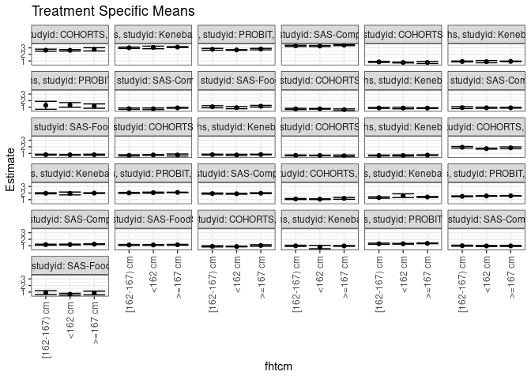

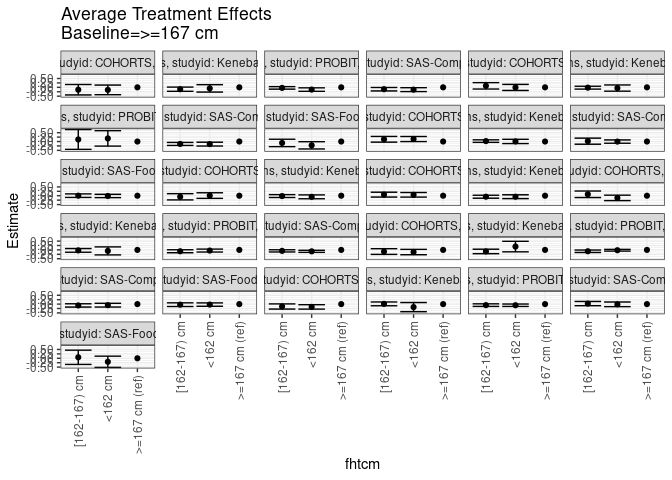

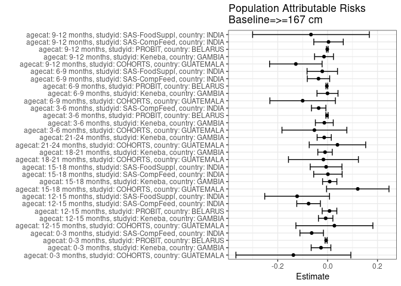

## Results Table

### Parameter: TSM

| agecat | studyid | country | intervention_level | baseline_level | estimate | ci_lower | ci_upper |
| --- | --- | --- | --- | --- | --- | --- | --- |
| 0-3 months | COHORTS | GUATEMALA | >=167 cm | NA | 2.7726124 | 2.5220732 | 3.0231517 |
| 0-3 months | COHORTS | GUATEMALA | <162 cm | NA | 2.6282917 | 2.5104756 | 2.7461078 |
| 0-3 months | COHORTS | GUATEMALA | [162-167) cm | NA | 2.6377953 | 2.4793852 | 2.7962055 |
| 0-3 months | Keneba | GAMBIA | >=167 cm | NA | 3.1208628 | 3.0514482 | 3.1902774 |
| 0-3 months | Keneba | GAMBIA | <162 cm | NA | 3.0625436 | 2.8654489 | 3.2596383 |
| 0-3 months | Keneba | GAMBIA | [162-167) cm | NA | 3.0151475 | 2.9189316 | 3.1113634 |
| 0-3 months | PROBIT | BELARUS | >=167 cm | NA | 2.8099946 | 2.6988185 | 2.9211707 |
| 0-3 months | PROBIT | BELARUS | <162 cm | NA | 2.6833900 | 2.6221200 | 2.7446601 |
| 0-3 months | PROBIT | BELARUS | [162-167) cm | NA | 2.7783986 | 2.6393035 | 2.9174936 |
| 0-3 months | SAS-CompFeed | INDIA | >=167 cm | NA | 3.4087865 | 3.3335492 | 3.4840239 |
| 0-3 months | SAS-CompFeed | INDIA | <162 cm | NA | 3.2777182 | 3.1940548 | 3.3613816 |
| 0-3 months | SAS-CompFeed | INDIA | [162-167) cm | NA | 3.3024042 | 3.2049419 | 3.3998665 |
| 3-6 months | COHORTS | GUATEMALA | >=167 cm | NA | 1.8509618 | 1.7116626 | 1.9902610 |
| 3-6 months | COHORTS | GUATEMALA | <162 cm | NA | 1.7278269 | 1.6584971 | 1.7971568 |
| 3-6 months | COHORTS | GUATEMALA | [162-167) cm | NA | 1.9320022 | 1.8105425 | 2.0534619 |
| 3-6 months | Keneba | GAMBIA | >=167 cm | NA | 1.9926789 | 1.9365373 | 2.0488204 |
| 3-6 months | Keneba | GAMBIA | <162 cm | NA | 1.9364524 | 1.7175035 | 2.1554013 |
| 3-6 months | Keneba | GAMBIA | [162-167) cm | NA | 1.9657025 | 1.8780128 | 2.0533922 |
| 3-6 months | PROBIT | BELARUS | >=167 cm | NA | 2.0942054 | 2.0530385 | 2.1353723 |
| 3-6 months | PROBIT | BELARUS | <162 cm | NA | 2.0571454 | 1.9722873 | 2.1420036 |
| 3-6 months | PROBIT | BELARUS | [162-167) cm | NA | 2.0179984 | 1.9348780 | 2.1011187 |
| 3-6 months | SAS-CompFeed | INDIA | >=167 cm | NA | 1.9739693 | 1.9067973 | 2.0411413 |
| 3-6 months | SAS-CompFeed | INDIA | <162 cm | NA | 1.8933467 | 1.8219842 | 1.9647092 |
| 3-6 months | SAS-CompFeed | INDIA | [162-167) cm | NA | 1.9199326 | 1.8314783 | 2.0083869 |
| 6-9 months | COHORTS | GUATEMALA | >=167 cm | NA | 1.1892152 | 1.0491952 | 1.3292352 |
| 6-9 months | COHORTS | GUATEMALA | <162 cm | NA | 1.0684200 | 1.0106551 | 1.1261848 |
| 6-9 months | COHORTS | GUATEMALA | [162-167) cm | NA | 1.0962691 | 1.0172012 | 1.1753370 |
| 6-9 months | Keneba | GAMBIA | >=167 cm | NA | 1.3971472 | 1.3218369 | 1.4724576 |
| 6-9 months | Keneba | GAMBIA | <162 cm | NA | 1.5874870 | 1.2991921 | 1.8757819 |
| 6-9 months | Keneba | GAMBIA | [162-167) cm | NA | 1.3106010 | 1.2095775 | 1.4116245 |

[output cut: 63 more lines]

### Parameter: E(Y)

| agecat | studyid | country | intervention_level | baseline_level | estimate | ci_lower | ci_upper |
| --- | --- | --- | --- | --- | --- | --- | --- |
| 0-3 months | COHORTS | GUATEMALA | NA | NA | 2.6353712 | 2.5465302 | 2.7242122 |
| 0-3 months | Keneba | GAMBIA | NA | NA | 3.0944274 | 3.0398727 | 3.1489822 |
| 0-3 months | PROBIT | BELARUS | NA | NA | 2.8040155 | 2.6922827 | 2.9157483 |
| 0-3 months | SAS-CompFeed | INDIA | NA | NA | 3.3449470 | 3.2851675 | 3.4047265 |
| 3-6 months | COHORTS | GUATEMALA | NA | NA | 1.7979953 | 1.7423030 | 1.8536877 |
| 3-6 months | Keneba | GAMBIA | NA | NA | 1.9794873 | 1.9347361 | 2.0242384 |
| 3-6 months | PROBIT | BELARUS | NA | NA | 2.0917916 | 2.0507260 | 2.1328572 |
| 3-6 months | SAS-CompFeed | INDIA | NA | NA | 1.9381168 | 1.8722991 | 2.0039344 |
| 6-9 months | COHORTS | GUATEMALA | NA | NA | 1.0891323 | 1.0450915 | 1.1331731 |
| 6-9 months | Keneba | GAMBIA | NA | NA | 1.3966930 | 1.3370412 | 1.4563449 |
| 6-9 months | PROBIT | BELARUS | NA | NA | 1.5711878 | 1.5417167 | 1.6006589 |
| 6-9 months | SAS-CompFeed | INDIA | NA | NA | 1.2144768 | 1.1795030 | 1.2494506 |
| 6-9 months | SAS-FoodSuppl | INDIA | NA | NA | 1.1405137 | 1.0997387 | 1.1812887 |
| 9-12 months | COHORTS | GUATEMALA | NA | NA | 0.9293038 | 0.8874492 | 0.9711585 |
| 9-12 months | Keneba | GAMBIA | NA | NA | 0.9708891 | 0.9222915 | 1.0194866 |
| 9-12 months | PROBIT | BELARUS | NA | NA | 1.3751690 | 1.3226496 | 1.4276884 |
| 9-12 months | SAS-CompFeed | INDIA | NA | NA | 0.9930838 | 0.9436059 | 1.0425616 |
| 9-12 months | SAS-FoodSuppl | INDIA | NA | NA | 0.7916715 | 0.6618281 | 0.9215150 |
| 12-15 months | COHORTS | GUATEMALA | NA | NA | 0.8018513 | 0.7601969 | 0.8435058 |
| 12-15 months | Keneba | GAMBIA | NA | NA | 0.9309324 | 0.8952046 | 0.9666602 |
| 12-15 months | PROBIT | BELARUS | NA | NA | 1.1801864 | 0.8594720 | 1.5009008 |
| 12-15 months | SAS-CompFeed | INDIA | NA | NA | 0.8285766 | 0.7562994 | 0.9008539 |
| 12-15 months | SAS-FoodSuppl | INDIA | NA | NA | 1.0258822 | 0.9363066 | 1.1154578 |
| 15-18 months | COHORTS | GUATEMALA | NA | NA | 0.7314958 | 0.6886307 | 0.7743608 |
| 15-18 months | Keneba | GAMBIA | NA | NA | 0.8726682 | 0.8384641 | 0.9068722 |
| 15-18 months | SAS-CompFeed | INDIA | NA | NA | 0.9190004 | 0.8846761 | 0.9533247 |
| 15-18 months | SAS-FoodSuppl | INDIA | NA | NA | 0.7935645 | 0.7577956 | 0.8293333 |
| 18-21 months | COHORTS | GUATEMALA | NA | NA | 0.7418707 | 0.7002233 | 0.7835182 |
| 18-21 months | Keneba | GAMBIA | NA | NA | 0.8178809 | 0.7819425 | 0.8538193 |
| 21-24 months | COHORTS | GUATEMALA | NA | NA | 0.6767187 | 0.6431305 | 0.7103068 |
| 21-24 months | Keneba | GAMBIA | NA | NA | 0.7242397 | 0.6859939 | 0.7624856 |

### Parameter: ATE

| agecat | studyid | country | intervention_level | baseline_level | estimate | ci_lower | ci_upper |
| --- | --- | --- | --- | --- | --- | --- | --- |
| 0-3 months | COHORTS | GUATEMALA | >=167 cm | >=167 cm | 0.0000000 | 0.0000000 | 0.0000000 |
| 0-3 months | COHORTS | GUATEMALA | <162 cm | >=167 cm | -0.1443208 | -0.4173564 | 0.1287149 |
| 0-3 months | COHORTS | GUATEMALA | [162-167) cm | >=167 cm | -0.1348171 | -0.4304449 | 0.1608106 |
| 0-3 months | Keneba | GAMBIA | >=167 cm | >=167 cm | 0.0000000 | 0.0000000 | 0.0000000 |
| 0-3 months | Keneba | GAMBIA | <162 cm | >=167 cm | -0.0583192 | -0.2675584 | 0.1509200 |
| 0-3 months | Keneba | GAMBIA | [162-167) cm | >=167 cm | -0.1057153 | -0.2243881 | 0.0129575 |
| 0-3 months | PROBIT | BELARUS | >=167 cm | >=167 cm | 0.0000000 | 0.0000000 | 0.0000000 |
| 0-3 months | PROBIT | BELARUS | <162 cm | >=167 cm | -0.1266046 | -0.2245355 | -0.0286737 |
| 0-3 months | PROBIT | BELARUS | [162-167) cm | >=167 cm | -0.0315961 | -0.1021832 | 0.0389911 |
| 0-3 months | SAS-CompFeed | INDIA | >=167 cm | >=167 cm | 0.0000000 | 0.0000000 | 0.0000000 |
| 0-3 months | SAS-CompFeed | INDIA | <162 cm | >=167 cm | -0.1310683 | -0.2403393 | -0.0217973 |
| 0-3 months | SAS-CompFeed | INDIA | [162-167) cm | >=167 cm | -0.1063823 | -0.2037344 | -0.0090303 |
| 3-6 months | COHORTS | GUATEMALA | >=167 cm | >=167 cm | 0.0000000 | 0.0000000 | 0.0000000 |
| 3-6 months | COHORTS | GUATEMALA | <162 cm | >=167 cm | -0.1231349 | -0.2764435 | 0.0301737 |
| 3-6 months | COHORTS | GUATEMALA | [162-167) cm | >=167 cm | 0.0810404 | -0.1025121 | 0.2645928 |
| 3-6 months | Keneba | GAMBIA | >=167 cm | >=167 cm | 0.0000000 | 0.0000000 | 0.0000000 |
| 3-6 months | Keneba | GAMBIA | <162 cm | >=167 cm | -0.0562264 | -0.2824847 | 0.1700318 |
| 3-6 months | Keneba | GAMBIA | [162-167) cm | >=167 cm | -0.0269763 | -0.1315987 | 0.0776460 |
| 3-6 months | PROBIT | BELARUS | >=167 cm | >=167 cm | 0.0000000 | 0.0000000 | 0.0000000 |
| 3-6 months | PROBIT | BELARUS | <162 cm | >=167 cm | -0.0370599 | -0.1202684 | 0.0461486 |
| 3-6 months | PROBIT | BELARUS | [162-167) cm | >=167 cm | -0.0762070 | -0.1599896 | 0.0075756 |
| 3-6 months | SAS-CompFeed | INDIA | >=167 cm | >=167 cm | 0.0000000 | 0.0000000 | 0.0000000 |
| 3-6 months | SAS-CompFeed | INDIA | <162 cm | >=167 cm | -0.0806226 | -0.1379816 | -0.0232635 |
| 3-6 months | SAS-CompFeed | INDIA | [162-167) cm | >=167 cm | -0.0540367 | -0.1162566 | 0.0081832 |
| 6-9 months | COHORTS | GUATEMALA | >=167 cm | >=167 cm | 0.0000000 | 0.0000000 | 0.0000000 |
| 6-9 months | COHORTS | GUATEMALA | <162 cm | >=167 cm | -0.1207953 | -0.2726717 | 0.0310812 |
| 6-9 months | COHORTS | GUATEMALA | [162-167) cm | >=167 cm | -0.0929461 | -0.2537893 | 0.0678971 |
| 6-9 months | Keneba | GAMBIA | >=167 cm | >=167 cm | 0.0000000 | 0.0000000 | 0.0000000 |
| 6-9 months | Keneba | GAMBIA | <162 cm | >=167 cm | 0.1903398 | -0.1080036 | 0.4886832 |
| 6-9 months | Keneba | GAMBIA | [162-167) cm | >=167 cm | -0.0865463 | -0.2129036 | 0.0398111 |

[output cut: 63 more lines]

### Parameter: PAR

| agecat | studyid | country | intervention_level | baseline_level | estimate | ci_lower | ci_upper |
| --- | --- | --- | --- | --- | --- | --- | --- |
| 0-3 months | COHORTS | GUATEMALA | >=167 cm | NA | -0.1372412 | -0.3676274 | 0.0931450 |
| 0-3 months | Keneba | GAMBIA | >=167 cm | NA | -0.0264354 | -0.0658803 | 0.0130095 |
| 0-3 months | PROBIT | BELARUS | >=167 cm | NA | -0.0059791 | -0.0101927 | -0.0017655 |
| 0-3 months | SAS-CompFeed | INDIA | >=167 cm | NA | -0.0638395 | -0.1109706 | -0.0167084 |
| 3-6 months | COHORTS | GUATEMALA | >=167 cm | NA | -0.0529665 | -0.1829919 | 0.0770590 |
| 3-6 months | Keneba | GAMBIA | >=167 cm | NA | -0.0131916 | -0.0490146 | 0.0226314 |
| 3-6 months | PROBIT | BELARUS | >=167 cm | NA | -0.0024137 | -0.0069245 | 0.0020970 |
| 3-6 months | SAS-CompFeed | INDIA | >=167 cm | NA | -0.0358525 | -0.0647720 | -0.0069330 |
| 6-9 months | COHORTS | GUATEMALA | >=167 cm | NA | -0.1000829 | -0.2314344 | 0.0312685 |
| 6-9 months | Keneba | GAMBIA | >=167 cm | NA | -0.0004542 | -0.0425793 | 0.0416709 |
| 6-9 months | PROBIT | BELARUS | >=167 cm | NA | -0.0030405 | -0.0064752 | 0.0003942 |
| 6-9 months | SAS-CompFeed | INDIA | >=167 cm | NA | -0.0365589 | -0.0814334 | 0.0083155 |
| 6-9 months | SAS-FoodSuppl | INDIA | >=167 cm | NA | -0.0213699 | -0.0824149 | 0.0396752 |
| 9-12 months | COHORTS | GUATEMALA | >=167 cm | NA | -0.1273664 | -0.2326624 | -0.0220703 |
| 9-12 months | Keneba | GAMBIA | >=167 cm | NA | -0.0144155 | -0.0523098 | 0.0234788 |
| 9-12 months | PROBIT | BELARUS | >=167 cm | NA | -0.0013342 | -0.0045646 | 0.0018963 |
| 9-12 months | SAS-CompFeed | INDIA | >=167 cm | NA | 0.0037185 | -0.0553934 | 0.0628305 |
| 9-12 months | SAS-FoodSuppl | INDIA | >=167 cm | NA | -0.0666535 | -0.3006143 | 0.1673072 |
| 12-15 months | COHORTS | GUATEMALA | >=167 cm | NA | 0.0272107 | -0.1271349 | 0.1815564 |
| 12-15 months | Keneba | GAMBIA | >=167 cm | NA | -0.0078108 | -0.0367399 | 0.0211183 |
| 12-15 months | PROBIT | BELARUS | >=167 cm | NA | 0.0076338 | -0.0216943 | 0.0369618 |
| 12-15 months | SAS-CompFeed | INDIA | >=167 cm | NA | -0.0762783 | -0.1236029 | -0.0289537 |
| 12-15 months | SAS-FoodSuppl | INDIA | >=167 cm | NA | -0.1222127 | -0.2520930 | 0.0076676 |
| 15-18 months | COHORTS | GUATEMALA | >=167 cm | NA | 0.1209084 | -0.0042844 | 0.2461013 |
| 15-18 months | Keneba | GAMBIA | >=167 cm | NA | 0.0084869 | -0.0201478 | 0.0371216 |
| 15-18 months | SAS-CompFeed | INDIA | >=167 cm | NA | 0.0012614 | -0.0557553 | 0.0582782 |
| 15-18 months | SAS-FoodSuppl | INDIA | >=167 cm | NA | -0.0060519 | -0.0696722 | 0.0575684 |
| 18-21 months | COHORTS | GUATEMALA | >=167 cm | NA | -0.0167084 | -0.1568876 | 0.1234708 |
| 18-21 months | Keneba | GAMBIA | >=167 cm | NA | -0.0103065 | -0.0392719 | 0.0186589 |
| 21-24 months | COHORTS | GUATEMALA | >=167 cm | NA | 0.0394985 | -0.0737132 | 0.1527101 |
| 21-24 months | Keneba | GAMBIA | >=167 cm | NA | -0.0136431 | -0.0420236 | 0.0147374 |